# Lecture 2: R Overview

# R Intro

## Why use R?

R is:

- a free public domain implementation of S,
- the standard among (academic) professional statisticians,
- available for Windows, Mac, and Linux,
- an object-oriented and functional programming structure, and
- designed to connect to high-performance programming languages like C, Fortran, and Julia.

## Why use R?

R has:

- an open-software environment with a large community that makes getting help easy,
- a massive set of packages for statistical modeling, data science, visualization, and importing and manipulating data,
- powerful tools for replicating and communicating your results,
- an interactive development environment (R Studio) tailored for interactive data analysis and statistical programmming,
- available for Windows, Mac, and Linux, and
- an object-oriented and functional programming structure.

## Reading Data files

The ability to datasets into R is an essential skill. For this class, most of the files will be on the course webpage and can be directly downloaded using `read.csv`. Consider the Seattle Housing dataset from Lab 1.

```r
Seattle <- read.csv(
  'http://math.montana.edu/ahoegh/teaching/stat408/datasets/SeattleHousing.csv',
  stringsAsFactors = F)
```

## Reading Data files

Recall we can also use the `read_csv()` function from the tidyverse.

```r
Seattle2 <- read_csv('http://math.montana.edu/ahoegh/teaching/stat408/datasets/SeattleHousing.csv')
```

## Viewing Data files

A common function that we will use is `head`, which shows the first few rows of a data frame.

```r
head(Seattle)
```

```
##     price bedrooms bathrooms sqft_living sqft_lot floors waterfront
## 1 1350000        3      2.50        2753    65005    1.0          1
## 2  228000        3      1.00        1190     9199    1.0          0
## 3  289000        3      1.75        1260     8400    1.0          0
## 4  720000        4      2.50        3450    39683    2.0          0
## 5  247500        3      1.75        1960    15681    1.0          0
## 6  850830        3      2.50        2070    13241    1.5          0
##   sqft_above sqft_basement zipcode     lat     long yr_sold mn_sold
## 1       2165           588   98070 47.4041 -122.451    2015       3
## 2       1190             0   98148 47.4258 -122.322    2014       9
## 3       1260             0   98148 47.4366 -122.335    2014       8
## 4       3450             0   98010 47.3420 -122.025    2015       3
## 5       1960             0   98032 47.3576 -122.277    2015       3
## 6       1270           800   98102 47.6415 -122.315    2014       6
```

# R Data Structures

## Data structure Overview

R has four common types of data structures:

- Vectors
- Matrices (and Arrays)
- Lists
- Data Frames (including tibbles)

## Data structure Overview

The base data structures in R can be organized by dimensionality and whether they are homogenous.

[output not shown]

## Vector Types

There are four common types of vectors: logical, integer, double (or numeric), and character. The `c()` function is used for combining elements into a vector

```r
dbl <- c(1,2.5,pi)
int <- c(1L,4L,10L)
log <- c(TRUE,FALSE,F,T)
char <- c('this is','a character string')
```

## Vector Types

They type of vector can be identified using the `typeof()` function. Note that only a single data type is allowed.

```r
  typeof(dbl)
```

```
## [1] "double"
```

```r
  comb <- c(char,dbl)
  typeof(comb)
```

```
## [1] "character"
```

```r
  comb
```

```
## [1] "this is"            "a character string" "1"
## [4] "2.5"                "3.14159265358979"
```

## Exercise: Vectors

Create a vector with your first, middle, and last names.

## Solution: Vectors

1. Create a vector with your first, middle, and last names.

```r
andy.names <- c("Andrew","Blake","Hoegh")
andy.names
```

```
## [1] "Andrew" "Blake"  "Hoegh"
```

## Logical Values in R (Conditions)

We have touched on many of these before, but here are some examples of expressions (conditions) in R. Evaluate these expressions:

```r
TRUE
```

```
## [1] TRUE
```

```r
pi > 3
```

```
## [1] TRUE
```

```r
pi == 3.14
```

```
## [1] FALSE
```

## Exercise: Conditions in R

Note that `&` is an and operator

```r
pi > 3 & pi < 3.5
c(1,3,5,7) %in% 1:3
1:3 %in% c(1,3,5,7)
```

## Solutions: Conditions in R: Evaluated

```r
pi > 3 & pi < 3.5
```

```
## [1] TRUE
```

```r
c(1,3,5,7) %in% 1:3
```

```
## [1]  TRUE  TRUE FALSE FALSE
```

```r
1:3 %in% c(1,3,5,7)
```

```
## [1]  TRUE FALSE  TRUE
```

## Data Frame Overview

A data frame:

- is the most common way of storing data in R
- is like a matrix with rows-and-column structure; however, unlike a matrix each column may have a different mode
- in a technical sense, a data frame is a list of equal-length vectors.

```r
df <- data.frame(x = 1:3, y = c('a','b','c'))
kable(df)
```

| x | y |
| --- | --- |
| 1 | a |
| 2 | b |
| 3 | c |

## tibble()

A modern data frame can be constructed using the `tibble()` command.

- The `read_csv` command creates a tibble rather than a data.frame.
- The tibble includes the type of each vector, and only prints a certain number of rows/columns.

```r
tibble1 <- tibble(x = 1:3, y = c('a','b','c')); tibble1
```

```
## # A tibble: 3 x 2
##       x y
##   <int> <chr>
## 1     1 a
## 2     2 b
## 3     3 c
```

# Subsetting

## Vector Subsetting: I

Subsetting allows you to extract elements from an object.

```r
num.vec <- seq(from = 1, to = 9, by = 1); num.vec
```

```
## [1] 1 2 3 4 5 6 7 8 9
```

```r
num.vec[1:3]
```

```
## [1] 1 2 3
```

```r
num.vec[c(1,5,8)]
```

```
## [1] 1 5 8
```

## Vector Subsetting: II

Subsetting also works with negative values or expressions.

```r
num.vec[-5]
```

```
## [1] 1 2 3 4 6 7 8 9
```

```r
num.vec[num.vec != 6]
```

```
## [1] 1 2 3 4 5 7 8 9
```

```r
num.vec[num.vec > 5]
```

```
## [1] 6 7 8 9
```

## Vector Subsetting: III

Another possibility is to use logical values directly.

```r
num.vec > 5
```

```
## [1] FALSE FALSE FALSE FALSE FALSE  TRUE  TRUE  TRUE  TRUE
```

```r
num.vec[num.vec > 5]
```

```
## [1] 6 7 8 9
```

```r
num.vec[rep(c(TRUE,FALSE,TRUE),each=3)]
```

```
## [1] 1 2 3 7 8 9
```

## Data Frame Subsetting: I

The same ideas apply to data frames, but the indices now constitute rows and columns of the data frame.

```r
df <- data.frame(x=1:3, y=3:1, z=c('a','b','c'))
df[,1]
```

```
## [1] 1 2 3
```

```r
df[-1,c(2:3)]
```

```
##   y z
## 2 2 b
## 3 1 c
```

## Data Frame Subsetting: II

There are also a couple built in functions in R for subsetting data frames.

```r
df$x
```

```
## [1] 1 2 3
```

```r
new.df <- subset(df, x >1); new.df
```

```
##   x y z
## 2 2 2 b
## 3 3 1 c
```

## Data Frame Subsetting: II

The `filter()` and `select()` functions in the `dplyr` package (in the tidyverse) can also be used for subsetting.

```r
df %>% select(x)
```

```
##   x
## 1 1
## 2 2
## 3 3
```

```r
filter(df, x > 1)
```

```
##   x y z
## 1 2 2 b
## 2 3 1 c
```

## Exercise: Subsetting

1. Create a new data frame that only includes houses worth more than $1,000,000.
2. From this new data frame what is the average living square footage of houses.

## Exercise: Subsetting - Solutions1

1. Create a new data frame that only includes houses worth more than $1,000,000.

```r
expensive_houses <- subset(Seattle, price > 1000000)
expensive_houses2 <- Seattle %>% filter(price > 1000000)
```

## Exercise: Subsetting - Solutions2

2. From this new data frame what is the average living square footage of houses. Hint columns in a data.frame can be indexed by `Seattle$sqft_living`

```r
mean(expensive_houses$sqft_living)
```

```
## [1] 3890.065
```

```r
Seattle %>% filter(price > 1000000) %>% summarize(ave_size = mean(sqft_living))
```

```
##   ave_size
## 1 3890.065
```

## Lists

Consider the two lists

```r
msu.info <- list( name = c('Waded Cruzado','Andy Hoegh'),
         degree.from = c('University of Texas at Arlington','Virginia Tech'),
         job.title = c('President', 'Assistant Professor of Statistics'))

msu.info2 <- list(c('Waded Cruzado','University of Texas at Arlington',
                     'President'), c('Andy Hoegh',
                  'Virginia Tech','Assistant Professor of Statistics'))
```

## List Output

```r
msu.info
```

```
## $name
## [1] "Waded Cruzado" "Andy Hoegh"
##
## $degree.from
## [1] "University of Texas at Arlington" "Virginia Tech"
##
## $job.title
## [1] "President"                         "Assistant Professor of Statistics"
```

```r
msu.info2
```

```
## [[1]]
## [1] "Waded Cruzado"                    "University of Texas at Arlington"
## [3] "President"
##
## [[2]]
## [1] "Andy Hoegh"                        "Virginia Tech"
## [3] "Assistant Professor of Statistics"
```

## Lists - indexing

With the current lists we can index elements using the double bracket `[[ ]]` notation or if names have been initialized, those can be used too.

So the first element of each list can be indexed

```r
msu.info[[1]]
```

```
## [1] "Waded Cruzado" "Andy Hoegh"
```

```r
msu.info$name
```

```
## [1] "Waded Cruzado" "Andy Hoegh"
```

## Exercise: Lists

Explore the indexing with these commands.

```r
msu.info <- list( name = c('Waded Cruzado','Andy Hoegh'),
         degree.from = c('University of Texas at Arlington','Virginia Tech'),
         job.title = c('President', 'Assistant Professor of Statistics'))
msu.info[1]
msu.info[[1]]
msu.info$name[2]
msu.info[1:2]
unlist(msu.info)
```

## Solution: Lists 1

```r
msu.info[1]
```

```
## $name
## [1] "Waded Cruzado" "Andy Hoegh"
```

```r
msu.info[[1]]
```

```
## [1] "Waded Cruzado" "Andy Hoegh"
```

```r
msu.info$name[2]
```

```
## [1] "Andy Hoegh"
```

## Solution: Lists 2

```r
msu.info[1:2]
```

```
## $name
## [1] "Waded Cruzado" "Andy Hoegh"
##
## $degree.from
## [1] "University of Texas at Arlington" "Virginia Tech"
```

```r
unlist(msu.info)
```

```
##                               name1                               name2
##                     "Waded Cruzado"                        "Andy Hoegh"
##                        degree.from1                        degree.from2
##  "University of Texas at Arlington"                     "Virginia Tech"
##                          job.title1                          job.title2
##                         "President" "Assistant Professor of Statistics"
```

## Lists - nested lists

```r
list(list('a','b'),list('c','d'))
```

```
## [[1]]
## [[1]][[1]]
## [1] "a"
##
## [[1]][[2]]
## [1] "b"
##
##
## [[2]]
## [[2]][[1]]
## [1] "c"
##
## [[2]][[2]]
## [1] "d"
```

## Arrays

Arrays are a general form a matrix, but have a higher dimension.

```r
array.1 <- array(1:8, dim=c(2,2,2)); array.1
```

```
## , , 1
##
##      [,1] [,2]
## [1,]    1    3
## [2,]    2    4
##
## , , 2
##
##      [,1] [,2]
## [1,]    5    7
## [2,]    6    8
```

```r
array.1[2,2,1]
```

```
## [1] 4
```

## Exercise: Arrays

Create an array of dimension 2 x 2 x 3, where each of the three 2 x 2 subarray (or matrix) is the Identity matrix.

## Solution: Arrays

Create an array of dimension 2 x 2 x 3, where each of the three 2 x 2 subarray (or matrix) is the Identity matrix.

```r
array(c(1,0,0,1), dim = c(2,2,3))
```

```
## , , 1
##
##      [,1] [,2]
## [1,]    1    0
## [2,]    0    1
##
## , , 2
##
##      [,1] [,2]
## [1,]    1    0
## [2,]    0    1
##
## , , 3
##
##      [,1] [,2]
## [1,]    1    0
## [2,]    0    1
```

# Graphics

## Basic Plotting in R: Scatterplot

For now, let’s consider some of the basic functionality in R.

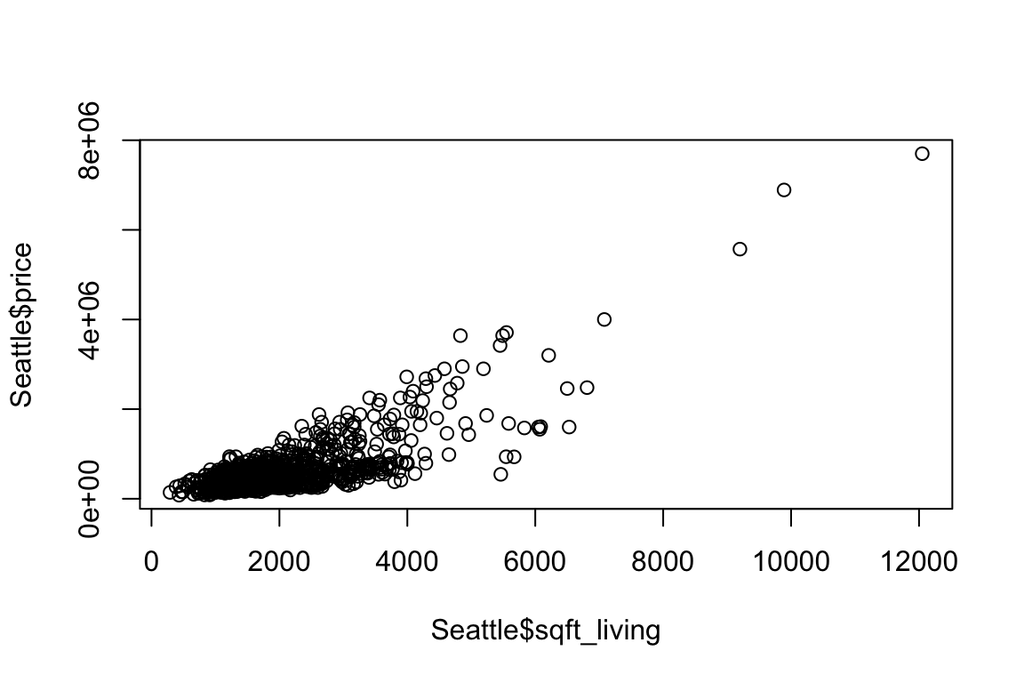

```r
plot(Seattle$price~Seattle$sqft_living)
```

## Basic Plotting in R: labels

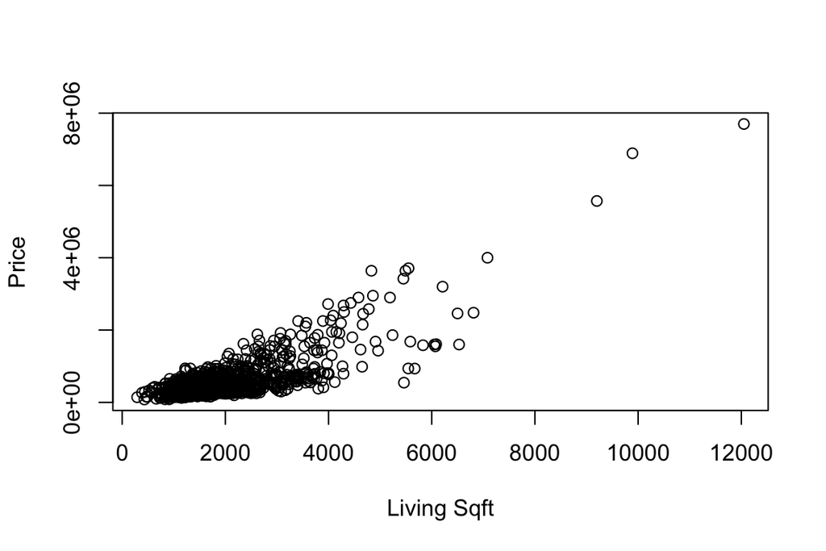

```r
plot(Seattle$price~Seattle$sqft_living,
     ylab='Price',xlab='Living Sqft')
```

## Basic Plotting in R: pch

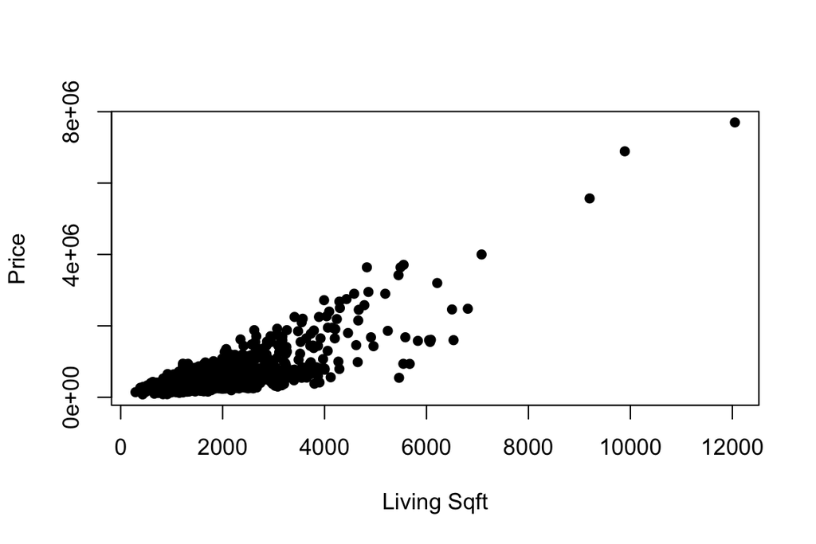

```r
plot(Seattle$price~Seattle$sqft_living,
     ylab='Price',xlab='Living Sqft', pch=16)
```

## Basic Plotting in R: color

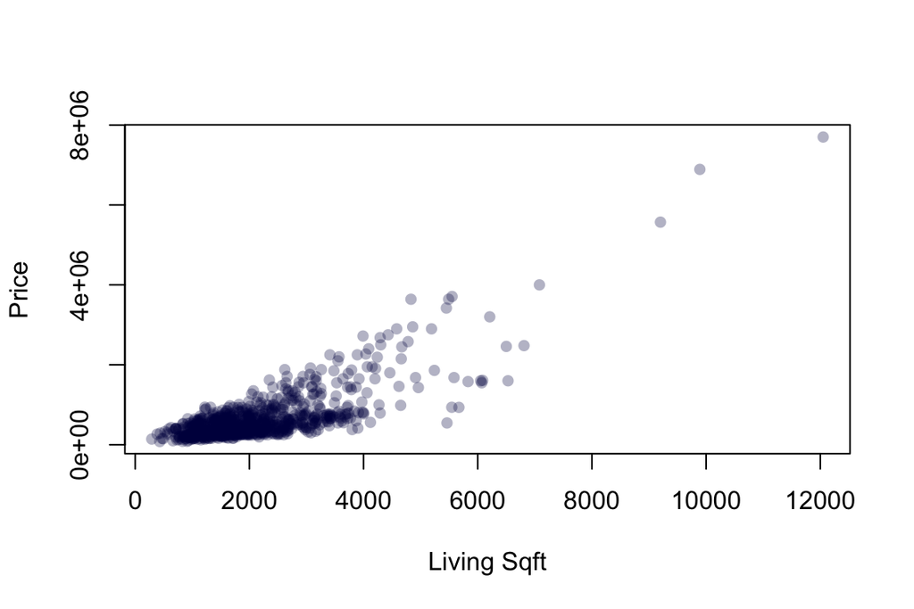

```r
plot(Seattle$price~Seattle$sqft_living, pch=16,
     col=rgb(0,0,.3,.3),ylab='Price',xlab='Living Sqft')
```

## Basic Plotting in R: title

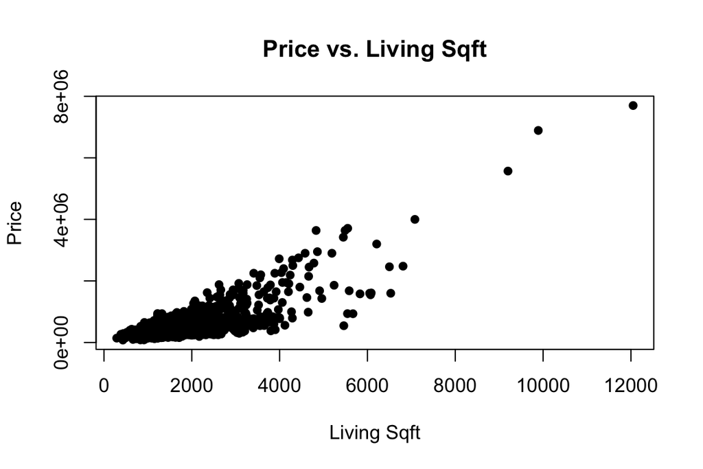

```r
plot(Seattle$price~Seattle$sqft_living, pch=16, ylab='Price',
     xlab='Living Sqft',main='Price vs. Living Sqft')
```

## Basic Plotting in R: histogram

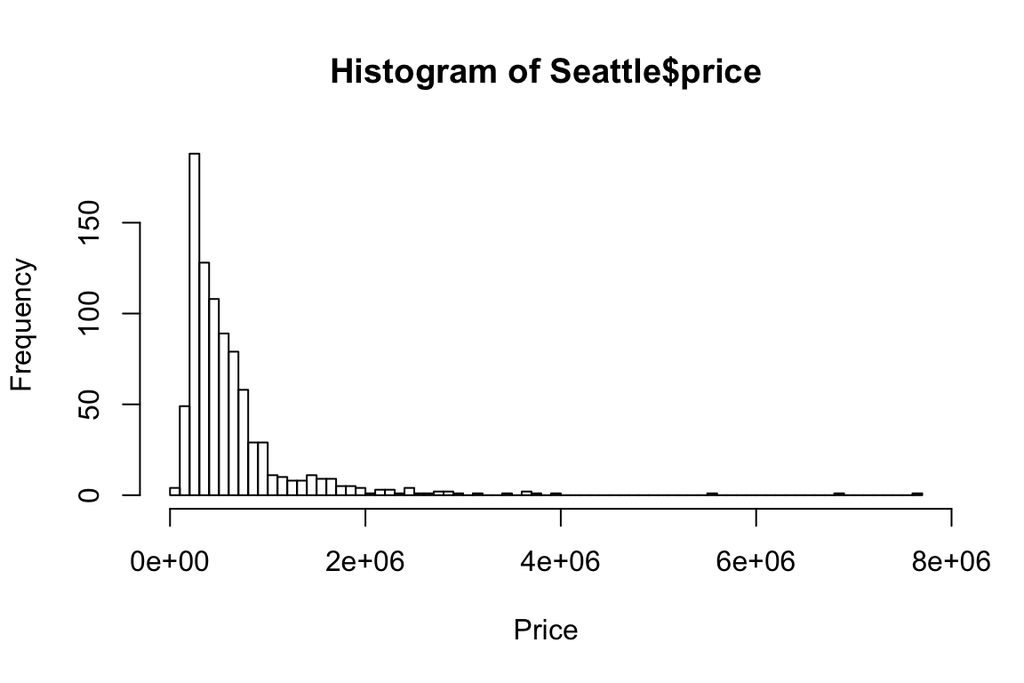

```r
hist(Seattle$price,xlab='Price', breaks='FD')
```

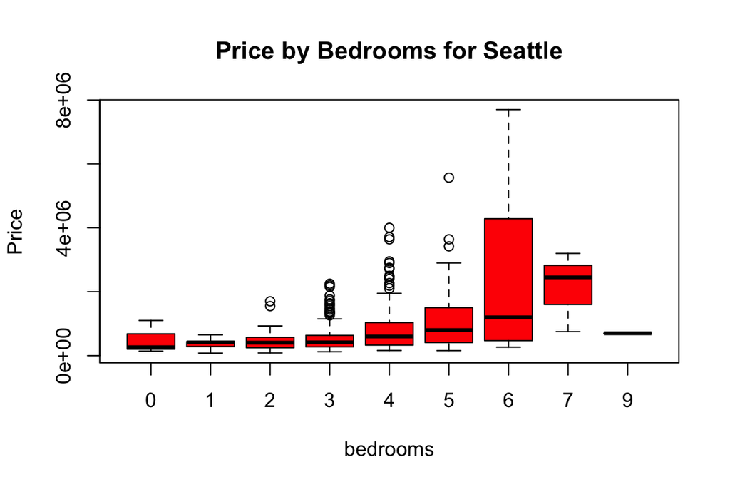

```r
boxplot(Seattle$price~Seattle$bedrooms,ylab='Price', col='red',
        xlab='bedrooms',main='Price by Bedrooms for Seattle')
```

## Exercise: Basic Plot

- Using only the subset of homes worth more than a million dollars, create a graphic.

## Solution: Basic Plot

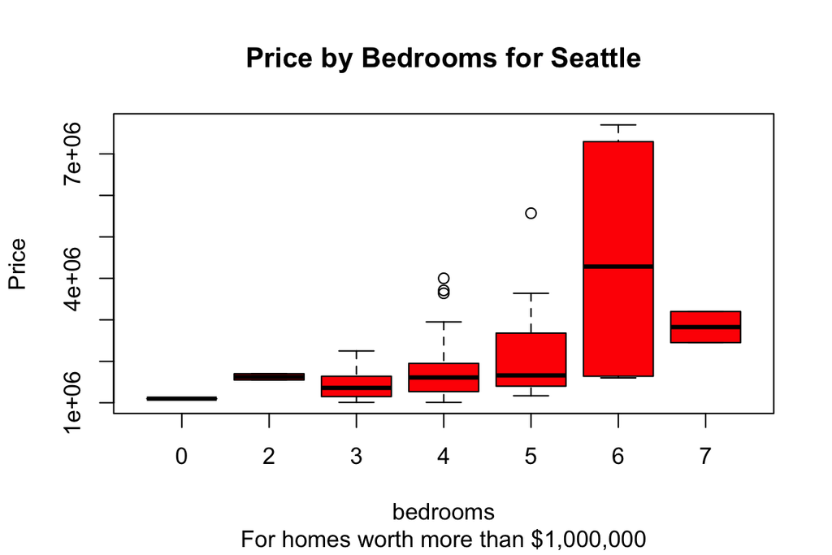

```r
boxplot(expensive_houses$price~expensive_houses$bedrooms,ylab='Price', col='red',
        xlab='bedrooms',main='Price by Bedrooms for Seattle',
        sub='For homes worth more than $1,000,000')
```